# Métodos de Regresión

Eduardo Aguilar (inspirado en INSEADAnalytics)

## AirBnB Pricing Tool

**Este caso está basado en el curso de analítica aplicada de INSEAD. Puede encontrar la solución original en el archivo [AirBnB Pricing Tool](http://inseaddataanalytics.github.io/INSEADAnalytics/groupprojects/January2018FBL/Airbnb_Pricing_TeamR_MASTER.HTML). Las modificaciones y soluciones alternativas son responsabilidad de Eduardo Aguilar**

## El contexto de negocios

AirBnB fue fundada en 2008 por Brian Cheski, Joe Gebbia y Nathan Blecharczyk como AirBed & Breakfast, un sitio de ventas online para servicios de hospedajes de corto tiempo que incluía personas comunes y profesionales dedicados a ese negocio. Con el paso de los años, el porcentaje de personas que se dedican profesionalmente a recibir huéspedes ha incrementado, y está comenzando a desplazar a las personas comunes que ponen sus propiedades en alquiler, amenazando la naturaleza y propuesta de valor de AirBnB que ofrecía servicios económicos y personalizados. En este contexto, el departamento de marketing desea iniciar una campaña para atraer más anfitriones privados. Para hacer esto, ellos solicitaron al departamento de analítica crear un modelo que ayudara a entender a anfitriones potenciales cuanto dinero podrían obtener por poner su propiedad a disposición de AirBnB.

Como plan piloto, Amsterdam fue elegida como una ciudad modelo con el servicio debido a su regulación “amigable” con AirBnB y alto número de clientes de estancias cortas. La solución presentada, sin embargo, está diseñada para ser independiente de la ciudad y por lo tanto, un proceso replicable en otras ciudades.

## Los datos

| Nombre | Descripción |
| --- | --- |
| room_id | ID de la habitación en alquiler |
| survey_id | ID de la consulta |
| host_id | ID del anfitrión |
| room_type | Casa completa, habitación privada o habitación compartida |
| city | Ciudad |
| neighborhood | Subregión de la ciudad en la que se hace la consulta (Bijlmer Centrum, Bijlmer Oost, Bos en Lommer, Buitenveldert / Zuidas, Centrum Oost, Centrum West, De Aker / Nieuw Sloten, De Baarsjes / Oud West, … |
| reviews | Número de revisiones que ha recibido. Como 70% de los huéspedes dan una revisión, este puede ser usado para estimar el número de visitas. Note que este estimado no será confiable para una lista lista … |
| overall_satisfaction | Rating promedio que recibió la unidad de todos los reviews, en escala de 1 al 5. |
| accommodates | Número de personas que pueden ser acomodadas |
| bedrooms | Número de cuartos en la unidad |
| minstay | Estadía mínima |
| latitude | Ubicación geográfica |
| longitude | Ubicación geográfica |
| last_modified | Fecha de consulta de los datos |
| price | Precio de la unidad |

Leyendo los datos:

```
## [1] "C:/Users/eduardo_canas/Documents/R/UCAanalytics/Sesiones/Sesiones_3_4_Regresion/AirBNB_prices"
```

|  | 01 | 02 | 03 | 04 | 05 |
| --- | --- | --- | --- | --- | --- |
| room_id | 10176931.00 | 8935871.00 | 14011697.00 | 6137978.00 | 18630616.00 |
| survey_id | 1476.00 | 1476.00 | 1476.00 | 1476.00 | 1476.00 |
| host_id | 49180562.00 | 46718394.00 | 10346595.00 | 8685430.00 | 70191803.00 |
| room_type | 3.00 | 3.00 | 3.00 | 3.00 | 3.00 |
| country | NA | NA | NA | NA | NA |
| city | 1.00 | 1.00 | 1.00 | 1.00 | 1.00 |
| borough | NA | NA | NA | NA | NA |
| neighborhood | 9.00 | 6.00 | 21.00 | 6.00 | 8.00 |
| reviews | 7.00 | 45.00 | 1.00 | 7.00 | 1.00 |
| overall_satisfaction | 4.50 | 4.50 | 0.00 | 5.00 | 0.00 |
| accommodates | 2.00 | 4.00 | 3.00 | 4.00 | 2.00 |
| bedrooms | 1.00 | 1.00 | 1.00 | 1.00 | 1.00 |
| bathrooms | NA | NA | NA | NA | NA |
| price | 156.00 | 126.00 | 132.00 | 121.00 | 93.00 |
| minstay | NA | NA | NA | NA | NA |
| name | 14075.00 | 16619.00 | 1056.00 | 3937.00 | 13113.00 |
| last_modified | 18723.00 | 18722.00 | 18721.00 | 18720.00 | 18719.00 |
| latitude | 52.36 | 52.38 | 52.34 | 52.38 | 52.37 |
| longitude | 4.89 | 4.90 | 4.94 | 4.89 | 4.85 |
| location | 3842.00 | 9635.00 | 12081.00 | 16295.00 | 15036.00 |

## Sacando estadísticas de las columnas

Vamos a ver que hay dentro de cada variable para decidir si vamos a botar algunas.

```
##     room_id           survey_id       host_id                    room_type
##  Min.   :    2818   Min.   :1476   Min.   :     2234   Entire home/apt:14978
##  1st Qu.: 6050608   1st Qu.:1476   1st Qu.:  7140879   Private room   : 3682
##  Median :12282874   Median :1476   Median : 19886414   Shared room    :   63
##  Mean   :11205678   Mean   :1476   Mean   : 35776117
##  3rd Qu.:16610843   3rd Qu.:1476   3rd Qu.: 52026801
##  Max.   :20003728   Max.   :1476   Max.   :141831915
##
##  country               city       borough
##  Mode:logical   Amsterdam:18723   Mode:logical
##  NA's:18723                       NA's:18723
##
##
##
##
##
##                     neighborhood     reviews       overall_satisfaction
##  De Baarsjes / Oud West   :3289   Min.   :  0.00   Min.   :0.000
##  De Pijp / Rivierenbuurt  :2378   1st Qu.:  2.00   1st Qu.:0.000
##  Centrum West             :2225   Median :  6.00   Median :4.500
##  Centrum Oost             :1730   Mean   : 16.74   Mean   :3.301
##  Westerpark               :1430   3rd Qu.: 17.00   3rd Qu.:5.000
##  Noord-West / Noord-Midden:1418   Max.   :532.00   Max.   :5.000
##  (Other)                  :6253
##   accommodates       bedrooms     bathrooms          price
##  Min.   : 1.000   Min.   : 0.00   Mode:logical   Min.   :  12.0
##  1st Qu.: 2.000   1st Qu.: 1.00   NA's:18723     1st Qu.: 108.0
##  Median : 2.000   Median : 1.00                  Median : 144.0
##  Mean   : 2.922   Mean   : 1.43                  Mean   : 166.6
##  3rd Qu.: 4.000   3rd Qu.: 2.00                  3rd Qu.: 192.0
##  Max.   :17.000   Max.   :10.00                  Max.   :6000.0
##
##  minstay                                      name
##  Mode:logical                                   :   52
##  NA's:18723     Amsterdam                       :   36
##                 Lovely apartment near Vondelpark:   10
##                 Beautiful apartment in Amsterdam:    8
##                 Cosy apartment in Amsterdam     :    8
##                 Magnificent panoramic city view :    8
##                 (Other)                         :18601
##                     last_modified      latitude       longitude
##  2017-07-22 16:05:12.257054:    1   Min.   :52.30   Min.   :4.763
##  2017-07-22 16:05:14.146183:    1   1st Qu.:52.36   1st Qu.:4.864
##  2017-07-22 16:05:14.149610:    1   Median :52.36   Median :4.886
##  2017-07-22 16:05:14.151986:    1   Mean   :52.37   Mean   :4.889
##  2017-07-22 16:05:14.158963:    1   3rd Qu.:52.37   3rd Qu.:4.907
##  2017-07-22 16:05:14.161714:    1   Max.   :52.42   Max.   :5.028
##  (Other)                   :18717
##                                                location
##  0101000020E610000000016BD5AE691340452C62D861304A40:    1
##  0101000020E610000000016BD5AE79134016F88A6EBD304A40:    1
##  0101000020E610000000016BD5AE9913401C7BF65CA62E4A40:    1
##  0101000020E610000000016BD5AEA91340713C9F01F52E4A40:    1
##  0101000020E61000000002D6AA5D8313401BB80375CA294A40:    1
##  0101000020E6100000001AA54BFF821340B020CD5834314A40:    1
##  (Other)                                           :18717
```

De acá es fácil determinar que algunas columnas no podremos utilizarlas para nuestro análisis, entonces simplemente vamos a deshacernos de ellas. No siempre es recomendado hacer esto, existen criterios de imputación de variables cuando se tienen datos faltantes.

## Eliminando filas innecesarias

Ya que hay columnas que están llenas de campos vacíos o extraños las vamos a eliminar para no tomarlas en el análisis. Después de limpiar deberían de quedar menos variables:

```
##  [1] "room_id"              "survey_id"            "host_id"
##  [4] "room_type"            "city"                 "neighborhood"
##  [7] "reviews"              "overall_satisfaction" "accommodates"
## [10] "bedrooms"             "price"                "name"
## [13] "last_modified"        "latitude"             "longitude"
## [16] "location"
```

## Explorando las variables

### Distribución de precios

Si se quiere pronosticar precios, lo primero que se debe tener es una idea de como están distribuidos los mismos. El método más común es haciendo un histograma de la variable:

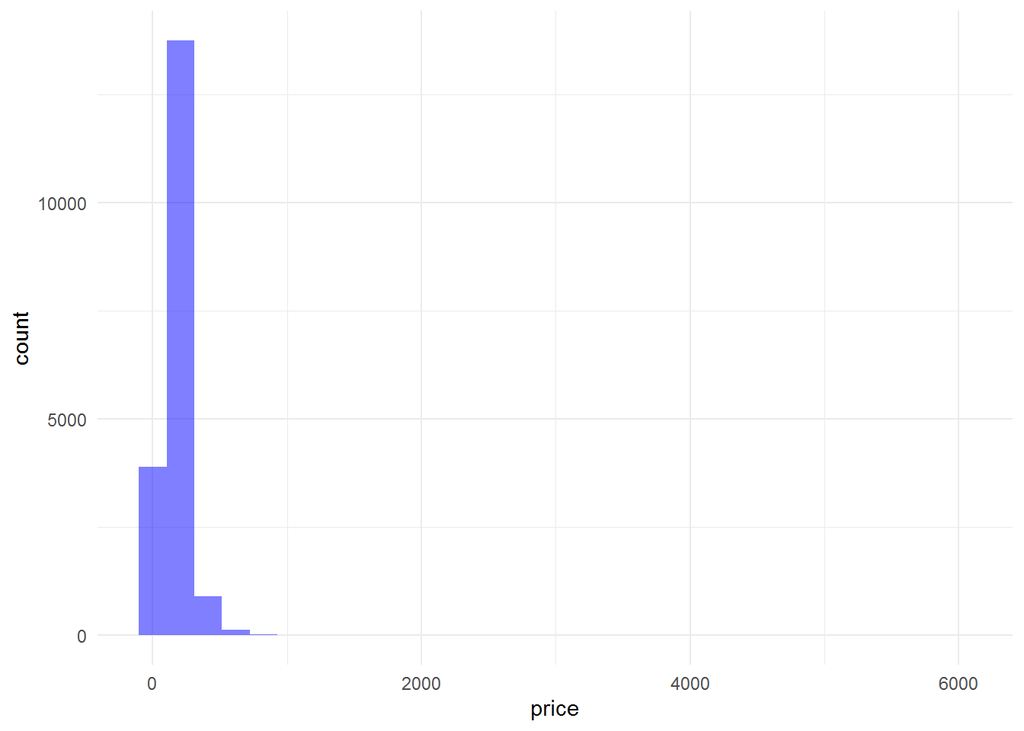

El problema con el histograma anterior es que hay demasiados outliers o valores extremos. Así se vuelve muy difícil visualizar cualquier tipo de correlación, y además, como muchos de estos modelos tienen soluciones numéricas, la convergencia de los mismos se vuelve extraña. Lo que vamos a hacer es tomar los datos entre los percentiles 1 y 99 para la variable precio.

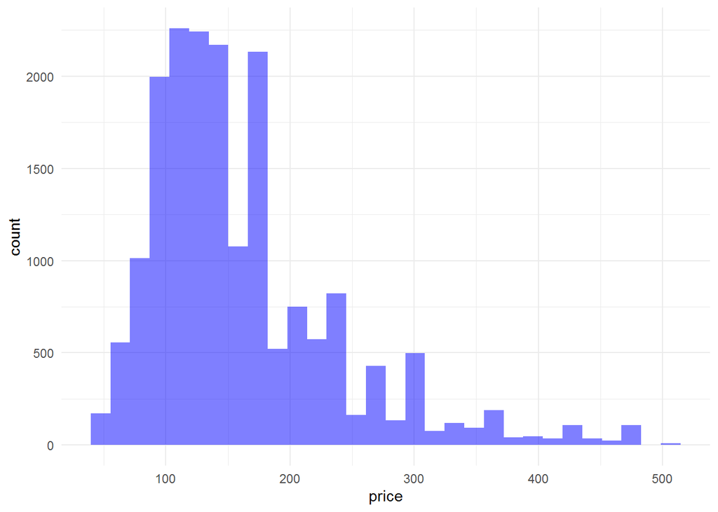

Este gráfico se ve mucho mejor, se puede observar que la mayor parte de los precios se ubican entre $100 y $200.

### Diagramas de dispersión

Cuando se trata de un problema de regresión o pronóstico, lo más apropiado es hacer un diagrama de dispersión. para verificar si los datos se distribuyen linealmente con respecto a alguna variable o ver algún tipo de correlación visual. Puede parecer demasiado empírico, y en efecto, estas metodologías son de naturaleza empírica, así que manos a la obra. Dado que algunas variables son categóricas, primero procederemos a crear variables dummy.

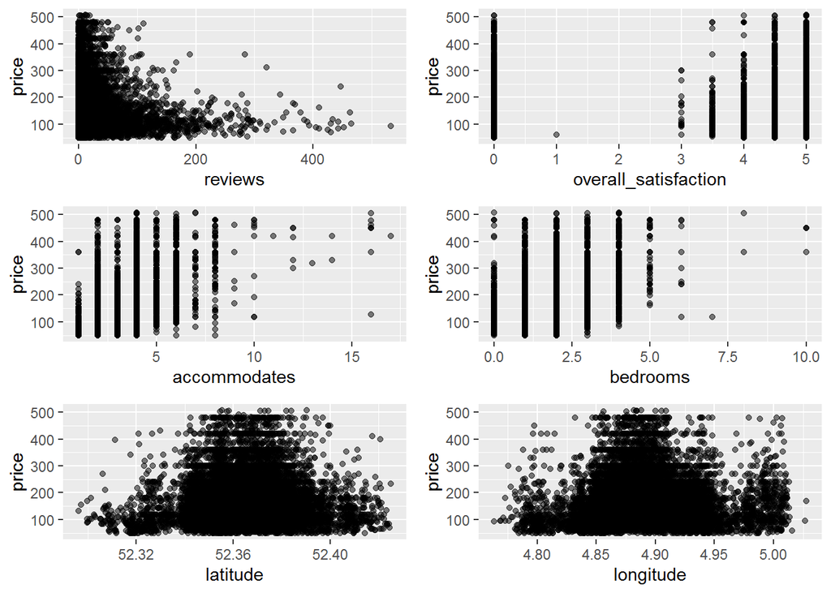

### Diagrama de caja de los vecindarios

Con los vecindarios dibujaremos individualmente el diagrama ya que son muchos. En este caso usaremos un boxplot porque es una visualización más para este tipo de variables categóricas.

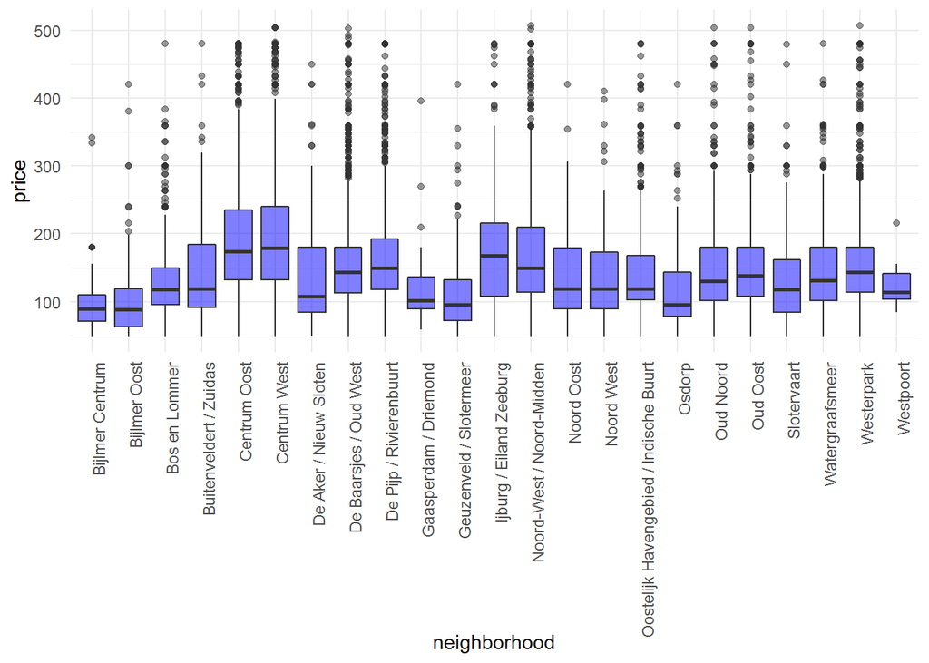

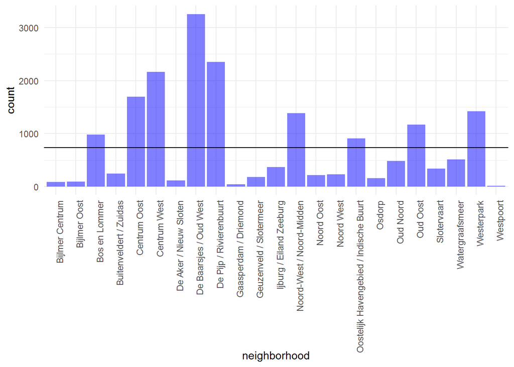

### Conteo de variables categóricas

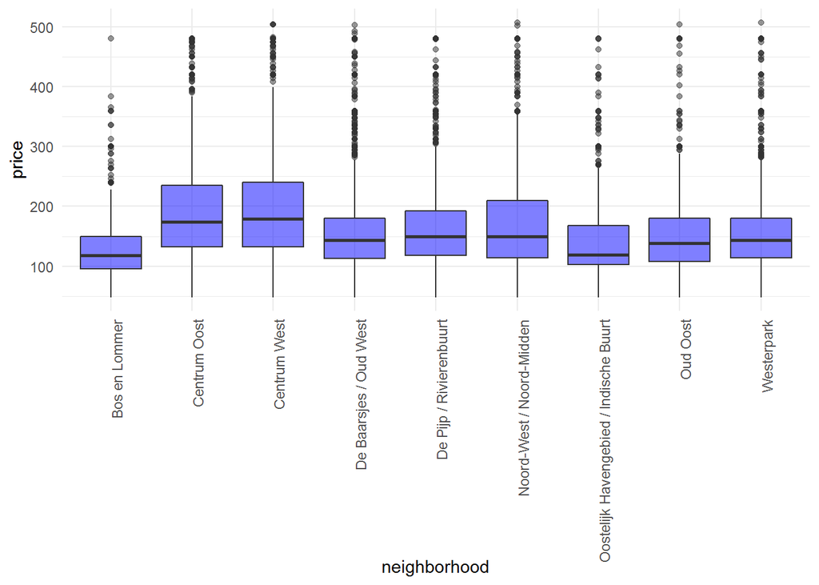

Ahora, después de ver estos diagramas, tiene un poco más de sentido incluir dichos vecindarios como potenciales variables de nuestro modelo, pues el precio medio depende de estos.

## Separando datos

Suponga que usted toma todos los datos y crea un modelo con una precisión casi perfecta que le permitiría predecir el precio de los alquileres de airbnb. ¿Tomaría usted la decisión de implementarlo inmediatamente? Por supuesto que es una decisión personal sin una respuesta correcta, pero en la práctica no se recomienda hacer eso. La razón es que todos los modelos deben ser validados estadísticamente para estar más seguros que su funcionamiento sea consistente en el tiempo. Más adelante veremos a detalle esta técnica, pero en este momento, simplemente dividiremos los datos en dos grupos: uno con el 90% y otro con el 10%.

Antes de hacer eso, tenemos que idear una manera de representar variables categóricas (cualitativas) como variables cuantitativas, la práctica más común es hacerlo con la técnica llamada One Hot encoding, que es, crear tantas variables como diferentes valores tenga una variable cuantitativa, las cuales tomarán el valor de 1 únicamente en la variable correspondiente al valor original y cero en las demás. Los modelos base de R como linear model (lm) pueden lidiar con variables categóricas fácilmente. Sin embargo, otro tipo de modelos no tiene esa funcionalidad, así que implementaremos esto desde antes:

El código de arriba habrá agregado nuevas columnas al dataframe b. Estas son algunas de las columnas que hemos añadido:

```
## [1] "room_typeEntire home/apt" "room_typePrivate room"
## [3] "room_typeShared room"     NA
## [5] NA                         NA
```

Ahora que ya tenemos codificadas las variables categóricas podemos proceder a separar los datos:

Al tener listos los datos, podemos pasar a crear nuestro modelo con los datos de entrenamiento (train_set).

## Modelo

Vamos a construir varios modelos y seleccionaremos el que funcione mejor. Nuevamente, eso puede sonar a que lo estamos a pura haciendo prueba y error, y en efecto esto así es, usted raramente encontrará el mejor modelo a la primera iteración. Tampoco encontraremos el mejor modelo en esta sesión, pero pretenedemos acercarnos a una solución subóptima que sea mejor que una solución aleatoria.

### Modelo 1: Regresión Lineal Clásica

|  | Estimate | Std. Error | t value | Pr(>\|t\|) |
| --- | --- | --- | --- | --- |
| (Intercept) | 30.3945750 | 6.4383865 | 4.7208373 | 0.0000024 |
| room_typePrivate room | -32.8045003 | 1.2246978 | -26.7857918 | 0.0000000 |
| room_typeShared room | -44.6435955 | 7.8263896 | -5.7042389 | 0.0000000 |
| neighborhoodBijlmer Oost | -2.9918963 | 8.8337601 | -0.3386889 | 0.7348484 |
| neighborhoodBos en Lommer | 15.9052190 | 6.5577883 | 2.4253938 | 0.0153024 |
| neighborhoodBuitenveldert / Zuidas | 21.8363591 | 7.2853508 | 2.9972969 | 0.0027279 |
| neighborhoodCentrum Oost | 76.1347502 | 6.4359606 | 11.8295861 | 0.0000000 |
| neighborhoodCentrum West | 85.0472683 | 6.4027244 | 13.2829813 | 0.0000000 |
| neighborhoodDe Aker / Nieuw Sloten | 22.0033239 | 8.3486027 | 2.6355697 | 0.0084075 |
| neighborhoodDe Baarsjes / Oud West | 43.0978069 | 6.3620324 | 6.7742200 | 0.0000000 |
| neighborhoodDe Pijp / Rivierenbuurt | 49.8594632 | 6.3956715 | 7.7958137 | 0.0000000 |
| neighborhoodGaasperdam / Driemond | 14.8313261 | 11.1978580 | 1.3244788 | 0.1853624 |
| neighborhoodGeuzenveld / Slotermeer | 9.2811140 | 7.6572489 | 1.2120690 | 0.2255033 |
| neighborhoodIjburg / Eiland Zeeburg | 17.5052205 | 6.9942863 | 2.5027887 | 0.0123315 |
| neighborhoodNoord-West / Noord-Midden | 49.6430471 | 6.4750700 | 7.6667970 | 0.0000000 |
| neighborhoodNoord Oost | 0.6798450 | 7.4477534 | 0.0912819 | 0.9272697 |
| neighborhoodNoord West | -2.3355086 | 7.3522878 | -0.3176574 | 0.7507488 |
| neighborhoodOostelijk Havengebied / Indische Buurt | 25.9127292 | 6.5714848 | 3.9432077 | 0.0000807 |
| neighborhoodOsdorp | 15.6716653 | 7.7873246 | 2.0124582 | 0.0441878 |
| neighborhoodOud Noord | 15.4956577 | 6.8228187 | 2.2711519 | 0.0231506 |
| neighborhoodOud Oost | 34.0687179 | 6.5158423 | 5.2285977 | 0.0000002 |
| neighborhoodSlotervaart | 15.4832303 | 7.0210399 | 2.2052617 | 0.0274495 |
| neighborhoodWatergraafsmeer | 23.1832906 | 6.7854838 | 3.4166010 | 0.0006356 |
| neighborhoodWesterpark | 43.6986962 | 6.4714267 | 6.7525599 | 0.0000000 |
| neighborhoodWestpoort | 18.2674649 | 17.2653097 | 1.0580444 | 0.2900506 |
| reviews | -0.0564772 | 0.0142670 | -3.9585982 | 0.0000757 |
| overall_satisfaction | -0.0382458 | 0.2069469 | -0.1848096 | 0.8533806 |
| accommodates | 21.8380238 | 0.5016481 | 43.5325566 | 0.0000000 |
| bedrooms | 21.6852633 | 0.7366971 | 29.4357948 | 0.0000000 |

```
## [1] "Modelo 1: 42.3596199141834"
```

La mayoría de variables son significativas con p-values pequeños.

### Evaluando los modelos

Luego de ajustar el/los modelo/s debemos evaluar el desempeño de los mismos. Para el caso de la regresión, la métrica a utilizar es llamada MAE (Mean Absolute Error) que en inglés significa Error Absoluto Medio. Estos son los resultados que deberíamos obtener:

```
## [1] "Modelo 1: 42.3596199141834"
```

### Modelo 2: Regresión log-lineal

Tomaremos como variables independientes room_type, neighborhood, reviews, overall_satisfaction, log(accommodates), bedrooms y haremos una regresión lineal respecto a log(precio). Luego, al hacer la predicción, recuperaremos el precio original haciendo exp(predicción) ya que está en escala logarítmica. Los resultados deberían ser similares a:

|  | Estimate | Std. Error | t value | Pr(>\|t\|) |
| --- | --- | --- | --- | --- |
| (Intercept) | 4.1651158 | 0.0350668 | 118.7764702 | 0.0000000 |
| room_typePrivate room | -0.2721888 | 0.0067131 | -40.5457155 | 0.0000000 |
| room_typeShared room | -0.3624047 | 0.0424903 | -8.5291141 | 0.0000000 |
| neighborhoodBijlmer Oost | -0.0384400 | 0.0479676 | -0.8013729 | 0.4229273 |
| neighborhoodBos en Lommer | 0.1627166 | 0.0356073 | 4.5697482 | 0.0000049 |
| neighborhoodBuitenveldert / Zuidas | 0.2047952 | 0.0395612 | 5.1766705 | 0.0000002 |
| neighborhoodCentrum Oost | 0.5275567 | 0.0349471 | 15.0958633 | 0.0000000 |
| neighborhoodCentrum West | 0.5758986 | 0.0347672 | 16.5644101 | 0.0000000 |
| neighborhoodDe Aker / Nieuw Sloten | 0.1807421 | 0.0453348 | 3.9868300 | 0.0000672 |
| neighborhoodDe Baarsjes / Oud West | 0.3384178 | 0.0345444 | 9.7966142 | 0.0000000 |
| neighborhoodDe Pijp / Rivierenbuurt | 0.3814888 | 0.0347277 | 10.9851587 | 0.0000000 |
| neighborhoodGaasperdam / Driemond | 0.1625469 | 0.0608070 | 2.6731613 | 0.0075214 |
| neighborhoodGeuzenveld / Slotermeer | 0.0880631 | 0.0415791 | 2.1179677 | 0.0341927 |
| neighborhoodIjburg / Eiland Zeeburg | 0.2033688 | 0.0379809 | 5.3545081 | 0.0000001 |
| neighborhoodNoord-West / Noord-Midden | 0.3688985 | 0.0351587 | 10.4923762 | 0.0000000 |
| neighborhoodNoord Oost | 0.0888692 | 0.0404423 | 2.1974325 | 0.0280034 |
| neighborhoodNoord West | 0.0643280 | 0.0399224 | 1.6113266 | 0.1071277 |
| neighborhoodOostelijk Havengebied / Indische Buurt | 0.2333705 | 0.0356828 | 6.5401357 | 0.0000000 |
| neighborhoodOsdorp | 0.1200704 | 0.0422867 | 2.8394334 | 0.0045249 |
| neighborhoodOud Noord | 0.1721297 | 0.0370495 | 4.6459332 | 0.0000034 |
| neighborhoodOud Oost | 0.2919588 | 0.0353794 | 8.2522175 | 0.0000000 |
| neighborhoodSlotervaart | 0.1458188 | 0.0381239 | 3.8248626 | 0.0001313 |
| neighborhoodWatergraafsmeer | 0.2171108 | 0.0368461 | 5.8923757 | 0.0000000 |
| neighborhoodWesterpark | 0.3441333 | 0.0351382 | 9.7936975 | 0.0000000 |
| neighborhoodWestpoort | 0.1654869 | 0.0937540 | 1.7651184 | 0.0775623 |
| reviews | -0.0003274 | 0.0000775 | -4.2247014 | 0.0000241 |
| overall_satisfaction | 0.0008418 | 0.0011238 | 0.7490796 | 0.4538199 |
| log(accommodates) | 0.3886536 | 0.0085646 | 45.3791933 | 0.0000000 |
| bedrooms | 0.1092113 | 0.0039049 | 27.9680679 | 0.0000000 |

Mientras que el error absoluto medio debería ser cercano a:

```
## [1] "Modelo 2: 41.1872432721441"
```

### Modelo 3: Arbol de regresión

En este caso estaríamos usando las mismas variables predictivas que en el modelo 1 pero con un árbol de regresión. Un árbol de regresión, al no ser un modelo paramétrico basado en supuestos probabilísticos, no debe ser evaluado de la misma forma, así que presentaremos los resultados después. Los resultados deberían ser similares a:

```
## [1] "Modelo 3: 44.5732099981253"
```

En este casi la regresión con árboles no funcionó tan bien, sin embargo podemos intentar con métodos aún más poderosos.

### Modelo 4: XGBoost

XGBoost es el nombre del paquete que efectua el algoritmo de Gradient Boosting Decision Tree, el cual es un árbol que se va desarrollando por etapas, y en cada etapa mejora usando como insumo el error de la etapa anterior. Como XGBoost es otro método basado en árboles, por lo tanto no hace ningún supuesto probabilístico, y tampoco es necesario evaluar el ajuste de la misma forma que con la regresión lineal.

Y al evaluar el modelo obtenemos:

```
## [1] "Modelo 4: 39.3170450293499"
```

## Comparando modelos

Se debe seleccionar un modelo a partir de sus resultados. En el caso de los 4 modelos anteriores nosotros habíamos utilizado la métrica MAE (Mean Absolute Error) que en inglés significa Error Absoluto Medio.

Ciertamente para el caso de la regresión lineal se deben evaluar muchos otros factores para asegurar la significancia estadística del modelo como normalidad, homecedasticidad, etc. Sin embargo, a la hora de comparar un modelo lineal con uno no lineal, no se pueden utilizar todos estos factores ya que no son parte de los supuestos. Es por eso que nos enfocaremos solamente en la desviación absoluta media. Retomando los valores que obtuvimos, los resultados habían sido estos:

```
## [1] "Modelo 1: 42.3596199141834"
```

```
## [1] "Modelo 2: 41.1872432721441"
```

```
## [1] "Modelo 3: 44.5732099981253"
```

```
## [1] "Modelo 4: 39.3170450293499"
```

Así que hasta el momento, el mejor modelo es el Modelo #4.

## Modelo 5: Ensamblando modelos 1 y 2 con los datos

Una técnica común en ciencia de datos es ensamblar modelos. La idea es seleccionar el resultado de modelos diferentes y construir en base a ellos un modelo que tenga un desempeño superior. Podemos construir una nueva base de datos que contenga las predicciones del modelo 1, las predicciones del modelo 2, así como las variables independientes originales: room_type, neighborhood, reviews, overall_satisfaction, accommodates, bedrooms. El resultado final de este modelo usualmente es superior a los modelos anteriores:

```
## [1] "Modelo 5: 39.2992562895236"
```

## Conclusiones

- Si se tienen modelos con resultados diferentes, es posible construir un modelo final que sea capaz de superar modelos anteriores simplemente ensamblando los resultados y aplicando XGboost.
- Las propiedades de homocedasticidad y pvalues son importantes mientras se considere únicamente modelos lineales que asuman normalidad, para modelos de regresión que no sean lineales la métrica de comparación más apropiada sería la desviación absoluta media o la desviación cuadrática media.
- Para mejorar los resultados debemos mejorar el análisis exploratorio, construir nuevas variables o mejorar los datos iniciales.

> Analítica de datos es un proceso iterativo, podríamos necesitar regresar a nuestros datos originales en cualquier momento y seleccionar nuevos atributos, así como diferentes herramientas de regresión y modelamiento.